# OSNOVE PROGRAMSKOG JEZIKA R

### Aspekti statistike i pozicije

```r
# budući da stalno koristimo istu "osnovicu" grafa možemo ju
# pohraniti u zasebnu varijablu npr. imena `graf`

graf <- ggplot(mtcars, aes(x = wt, y = mpg))

# dodajte varijabli `graf` geometriju točaka a potom linijsku geometriju
```

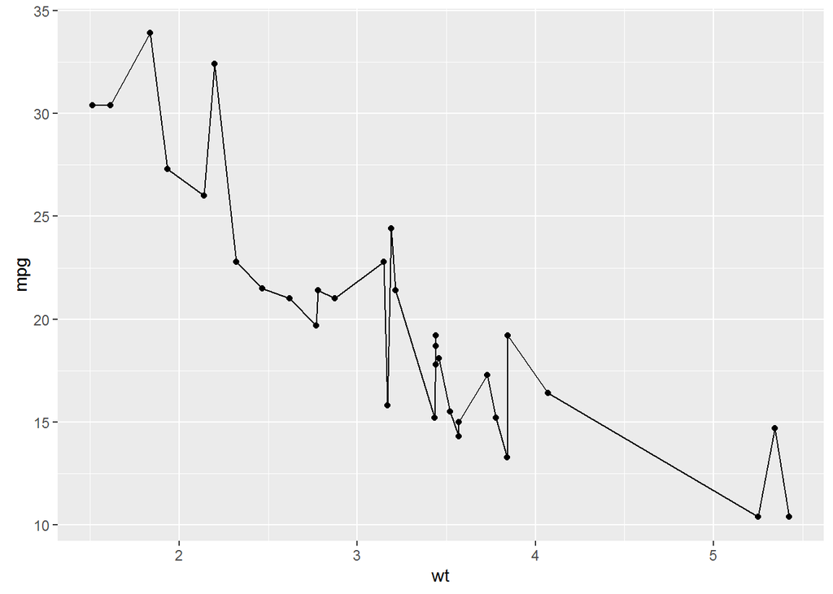

```r
graf + geom_point() + geom_line()
```

**Statistika** je aspekt koji provodi neke dodatne izračune nad podatkovnim skupom prije njegove vizualizacije. To su najčešće izračuni koje lako možemo i sami provesti “ručno”, no koje je puno praktičnije ostaviti na odgovornost vizualizacijskom alatu, pogotovo ako se radi o izračunu koji se koristi samo za potrebe vizualizacije i nije nam trajno potreban (npr. stupčasti graf - *bar chart* - prebrojava koliko puta se pojavljuje koja kategorijska varijabla i to prikazuje visinom stupca).

Većina statistika provode agregaciju, ali nije pravilo. Neke od češće korištenih statistika su:

- `count` - prebrojavanje pojava (za kategorijske varijable)
- `bin` - raspoređivanje pojava u ladice i prebrojavanje (za kontinuirane varijable)
- `smooth` - “zaglađivanje” tj. “usrednjenje” korištenjem odabrane metode (najčešće `lm` za linearno ili `loess` za zakrivljeno zaglađivanje)
- `unique` - uklanjanje duplikata
- `identity` - direktno preslikavanje, tj. “ostavljanje kako jest”

Ovo su samo neke statistike, sa dodatne se mogu naći u dokumentaciji.

Svaka statistika ima svoju pomoćnu funkciju koja prati oblik `stat_<ime_statistike>` i koja stvara vlastiti sloj vezan uz tu statistiku. Budući da kod grafova koji prikazuju agregirane vrijednosti sam prikaz nastaje kao kombinacija statistike (izračuna) i geometrije (vizualizacije tog izračuna), zapravo imamo mogućnost definiranja `geom` sloja sa `stat` parametrom ili `stat` sloja sa `geom` parametrom - pri čemu je izbor zapravo osobna preferenca programera budući da obje kombinacije daju identičan rezultat. U praksi su `geom` i `stat` funkcije već oblikovane tako da koriste “svoju” statistiku/geometriju tako da zapravo dodatni pripadajući parametar često ne moramo ni podešavati (tako npr. `geom_bar` već unaprijed koristi `count` statistiku, a ponaša se analogno `stat_count` funkciji koja već ima postavljenu `bar` geometriju).

Vratimo se na naš graf ovisnosti potrošnje o težini automobila, ali ovaj put umjesto dodavanja sloja linijske geometrije dodajmo sloj koji će prikazati “zaglađivanje” (tj. statistiku `smooth`). Ovo je odličan primjer korištenja statističkog aspekta - umjesto da se točke direktno povežu linijom, uz pomoć posebne funkcije ćemo “usrednjiti” vrijednosti a potom ćemo tako usrednjene vrijednosti povezati linijom ili krivuljom. Za ovo je idealna funkcija `stat_smooth` koja će - ukoliko koristimo default-ne parametre - stvoriti novi sloj sa “zaglađenim” prikazom osi *y* u ovisnosti o osi *x*, korištenjem tzv. `loess` metode, uz prikaz intervala pouzdanosti. Ovakav sloj možemo lako dodati već prije definiranoj varijabli graf.

```r
# dodajte geometriju točaka na varijablu `graf`
# te potom dodatni sloj sa krivuljom zaglađivanja
# koristite funkciju `stat_smooth` uz parametar `method`
# postavljen na `lm` (linearno zaglađivanje)
```

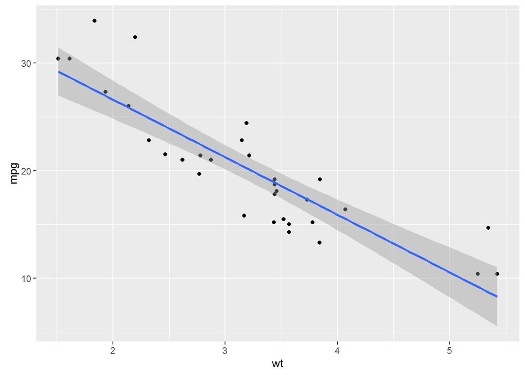

```r
graf + geom_point() + stat_smooth(method = 'lm')
```

```r
# ponovite postupak ali metodu zaglađivanja
# postavite na `loess`
```

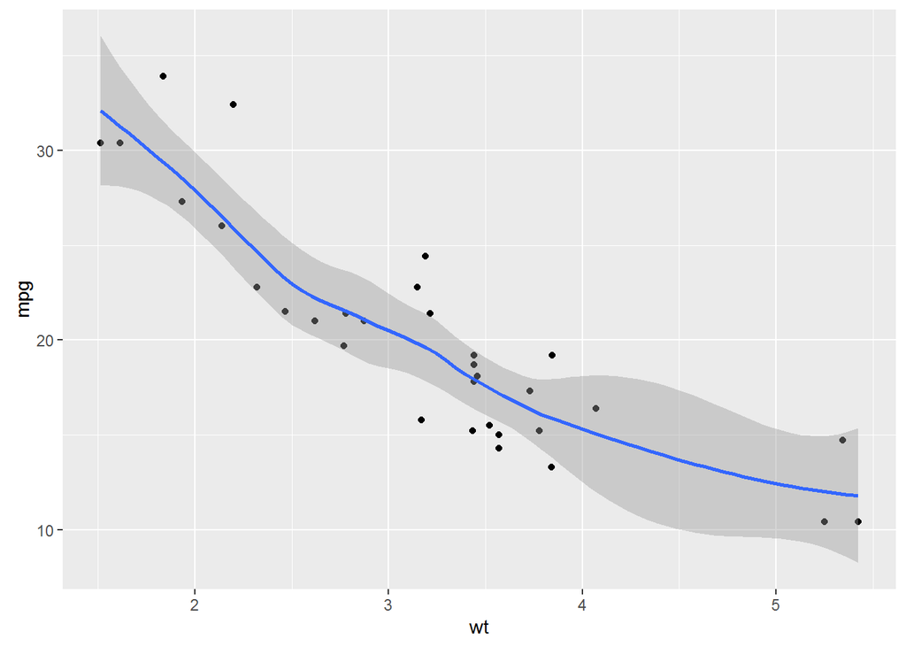

```r
graf + geom_point() + stat_smooth(method = 'loess')
```

```r
# stvorite još jednom isti graf ali sloju zaglađivanja
# dodajte estetiku `group` postavljenu na `cyl`
# Što smo ovime postigli?
```

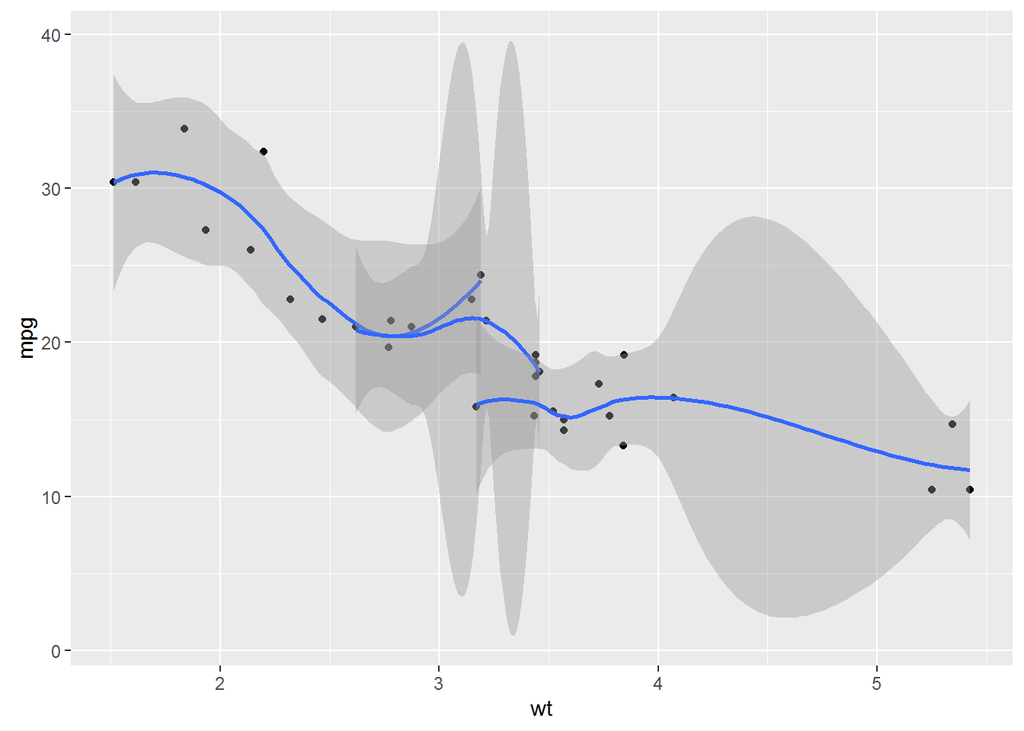

```r
graf + geom_point() + stat_smooth(aes(group = cyl), method = 'loess')
```

U zadnjem primjeru vidjeli smo tzv. `group` estetiku. Ona radi slično *group_by* funkciji iz SQL-a ili `dplyr`-a, tj. ako računamo agregacije nad nekim skupom podataka, onda se umjesto nad cijelim podatkovnim skupom one rade nad svakom definiranom grupom zasebno. Korištenjem ove estetike možemo na grafu prikazati zasebne izračune prema odabranoj grupi, pa tako je i u ovom primjeru zaglađivanje rađeno po “podgrupama” ovisno o broju cilindara.

Kod nekih vizualizacija može se dogoditi da su podaci već “grupirani” ali mi želimo dodati geometriju koja radi nad cijelim podatkovnim skupom - u tom slučaju najlakše je jednsotavno postaviti group estetiku na brojku 1, što će R interpretirati kao “sve je jedna grupa” te to tako i prikazati.

Iako smo u zadnjim primjerima koristili funkciju `stat_smooth` kako bismo naglasili kako se u primjeru računa određena statistika, u praksi se `geom` funkcije koriste nešto češće od `stat` funkcija, uglavnom zbog dosljednije sintakse (“crtamo” graf slaganjem geometrija jedne na drugu). Naravno, kao što je već rečeno, budući da `stat` i `geom` aspekti rade u paru, u praksi je svejedno koju pomoćnu funkciju odaberemo.

Pokušajmo sada napraviti stupčani graf (engl. *bar plot*) koji će visinom stupića prikazati broj pojavljivanja određene kategorije - npr. zastupljenost pojedinog broja cilindara u okviru `mtcars`. Za ovo koristimo pomoćnu funkciju `geom_bar` koja ima unaprijed postavljenu `count` statistiku.

```r
# nacrtajte stupčani graf varijable `cyl` tablice `mtcars`
# koristite funkciju `geom_bar` ili `stat_count`
```

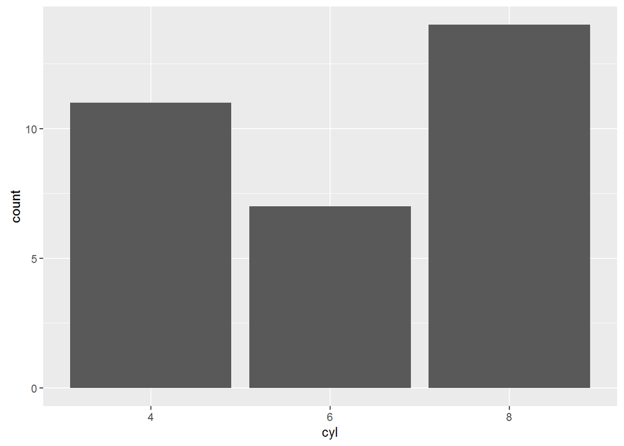

```r
ggplot(mtcars, aes(x = cyl)) + geom_bar()
```

Na sličan način možemo prikazati i kontinuirane varijable. Za razliku od stupčanog grafa, gdje imamo jasno definirane kategorije, ovdje ćemo morati prvo grupirati vrijednosti u tzv. “ladice” (engl. *bins*) na osnovu kojih gradimo graf koji se zove *histogram*. Opet koristimo bin statistiku, a za samo stvaranje histograma koristit ćemo pomoćnu funkciju geom_histogram.

```r
# nacrtajte histogram varijable `wt` tablice `mtcars`
# težine podijelite jednoliko u četiri ladice
# koristite funkciju `geom_histogram`
```

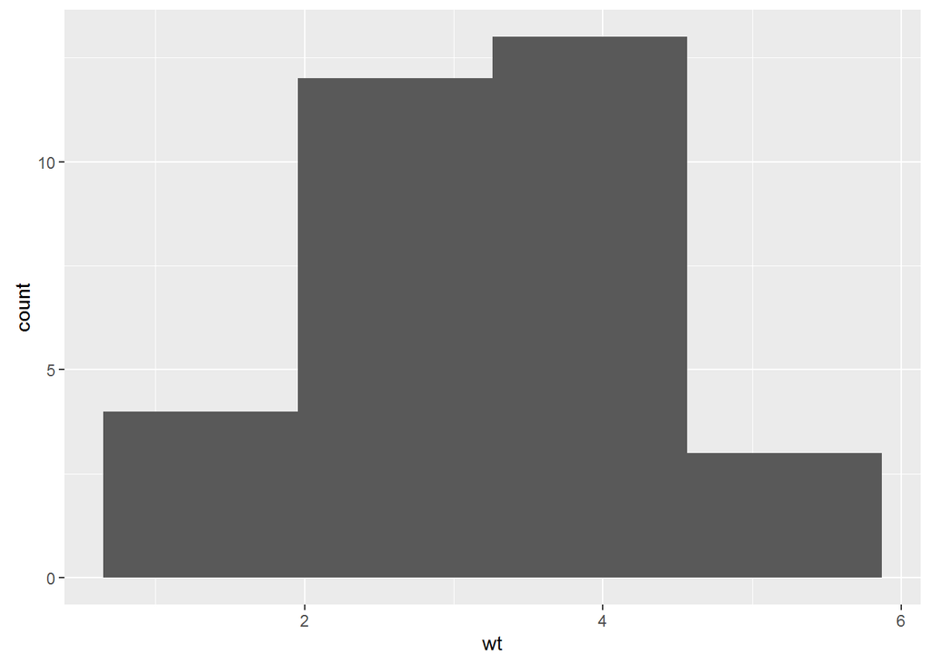

```r
ggplot(mtcars, aes(x = wt)) + geom_histogram(bins = 4)
```

Kako zapravo radi statistički aspekt? U pravilu se na osnovu postojećih varijabli izračunavaju jedna ili više novih, najčešće agregiranih varijabli. U dokumentaciji možemo naći konkretne informacije o nazivima tih novih varijabli i njihovom značenju. Na primjer, ako pogledamo dokumentaciju za funkciju `stat_bin`, možemo vidjeti da ona stvara varijable imena `count`, `ncount`, `density` i `ndensity`. Bilo koja od ovih varijabli može se koristiti kao “visina stupića”, tj. kao estetika *y*. Razlog zašto ovu estetiku nismo eksplicitno navodili u prethodnom primjeru jest činjenica da funkcija statistike automatski odabire onu agregatnu funkciju koja se očekivano najčešće koristi (u našem slučaju je to bila `count`). Ukoliko želimo obaviti neku drugu agregaciju, možemo i eksplicitno postaviti estetiku y na odabranu varijablu, samo moramo koristiti `ggplot2` konnvenciju gdje takvim varijablama kao prefiks i sufiks postavljamo `..`, kao npr:

```r
aes(x = hp, y = ..density..)
```

```
## * x -> hp
## * y -> ..density..
```

Pokušajmo ovo isprobati na primjeru.

```r
# nacrtajte histogram varijable `wt` tablice `mtcars`
# težine podijelite jednoliko u četiri ladice
# koristite funkciju `geom_histogram`
# za agregacijsku varijablu postavite `ncount`
# prokomentirajte dobiveni rezultat
```

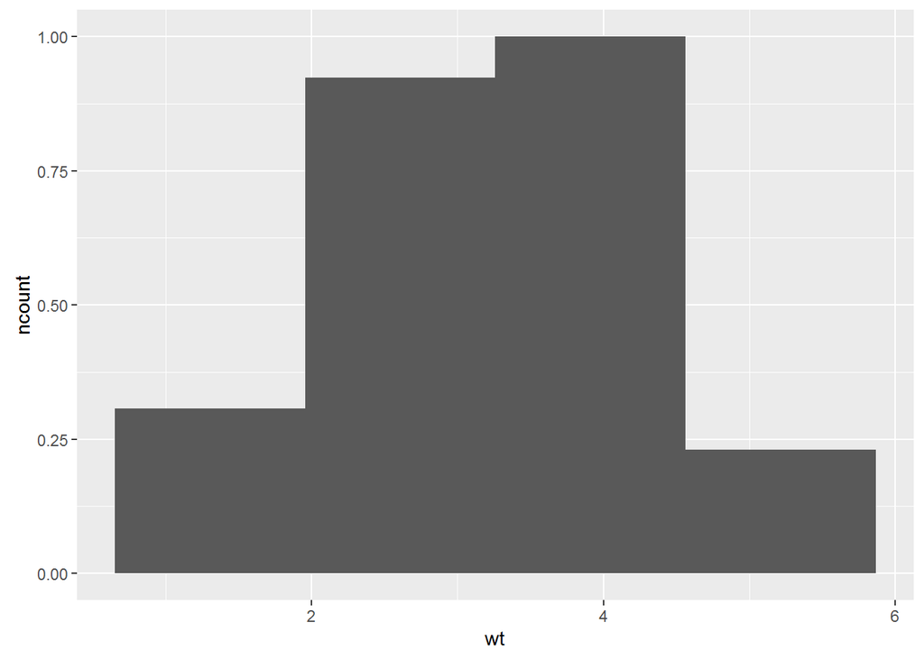

```r
ggplot(mtcars, aes(x = wt, y = ..ncount..)) + geom_histogram(bins = 4)
```

Otiđimo sada korak dalje. Nacrtajte isti histogram (sa *default*-nom `count` agregacijom), no prikažite na njemu i koliko je unutar svake kategorije zastupljen koji broj cilindara. Ovo ćete lako izvesti dodavanjem estetike `fill` koja reprezentira “punjenje” stupića bojom (za razliku od estetike `color` koja bi u slučaju stupčanog grafa bojala linije oko pravokutnika).

```r
# nacrtajte histogram varijable `wt`, uz dodanu varijablu `cyl` na estetici `fill`
```

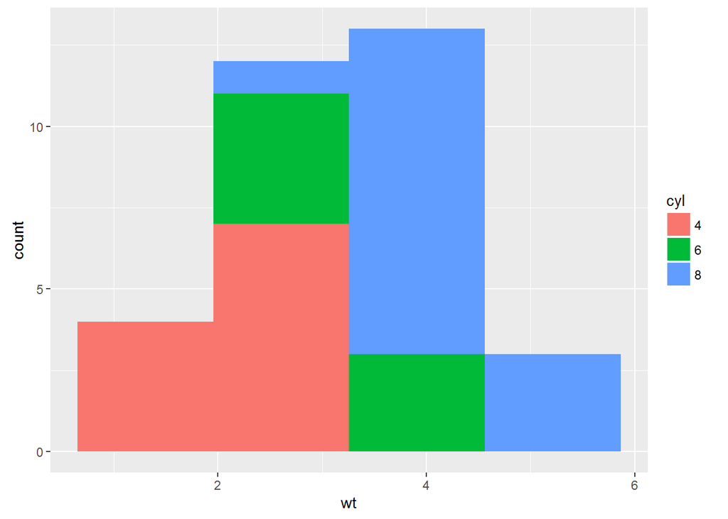

```r
ggplot(mtcars, aes(x = wt, fill = cyl)) + geom_histogram(bins = 4)
```

Ovdje vidimo primjer “kombiniranog” histograma - funkcija će zapravo izračunati frekvencije pojavljivanja za svaku kategoriju težine te za svaki broj cilindara. Jedan od načina kako ovo prikazati bio bi trodimenzionalni graf gdje bi u baznoj ravnini bile kombinacije dvije navedene varijable dok bi treća dimenzija bila rezervirana za visinu stupića - no kod projekcije takvog grafa na dvodimenzionalnu ravninu stupići bi se međusobno prekrivali. Kako bi se rezultati mogli učinkovito prikazati na dvodimenzionalnom grafu, stupići su “repozicionirani” tako da su je stupić za pojedine cilindre postavljen jedan na drugi u sklopu iste kategorije težine. Ovo je zapravo primjer korištenja tzv. *pozicijskog aspekta* ili jednostavno *pozicije*.

**Pozicija** je aspekt koji omogućuje “razmještanje” određenog aspekta grafa ukoliko je to potrebno zbog jasnoće prikaza. U prethodnom primjeru već smo uočili “raslojavanje” stupića prema kategorijskoj varijabli. U ovom slučaju funkcija je zapravo koristila pozicijski aspekt `"stack"` koji “male” stupiće razmješta tako da ih slaže jedan na drugi. Alternativa je postavljanje aspekta pozicije (position) na “izbjegavanje” - `"dodge"`- kod kojeg će stupići biti nacrtani u grupicama jedan pored drugog.

```r
# nacrtajte isti histogram, ali pozicijski aspekt `position` postavite na `"dodge"`
```

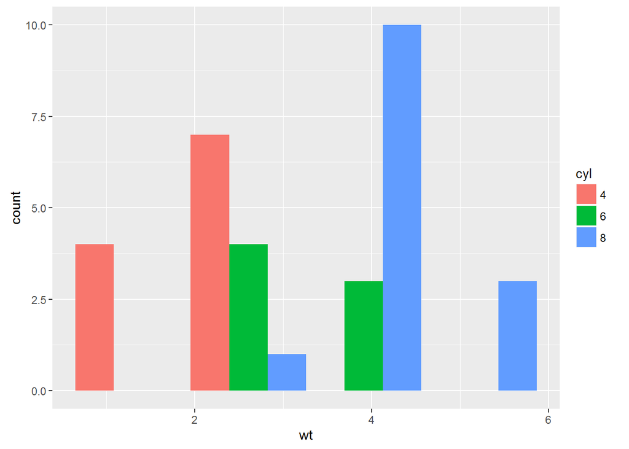

```r
ggplot(mtcars, aes(x = wt, fill = cyl)) + geom_histogram(bins = 4, position = "dodge")
```

Uočite da smo korištenjem “izbjegavanja” izgubili precizan prikaz intervala pojedine ladice, ali smo dobili jasniji prikaz odnosa između zastupljenosti pojedinih kategorija unutar pojedine ladice.